# midterm1 Extra Credit review sheet

## Inheritance of Theme Elements

The first three elements in [ggplot-themes](http://docs.ggplot2.org/current/theme.html) are `text`, `line` and `rect`, which, not coincidentally, are the same as the names of the basic theme element functions. Other theme elements inherit the values of these theme elements. For example, the theme elements `axis.text`, `legend.text`, `strip.text` and `axis.title` all inherit from text, while `axis.text.x` and `axis.text.y` further inherit from `axis.text`. This means the values of the components of the theme element text are passed on to axis.text as well as other elements that inherit from text or its children. You can override the default values of one or more theme elements by calling `theme()` and modifying the desired properties of theme elements therein.

Here is an example:

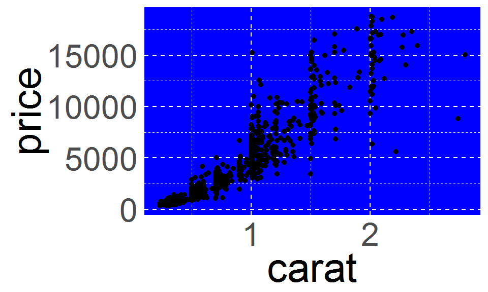

```r
set.seed(123)

df <- diamonds[sample(1:nrow(diamonds), size = 1000),]

df %>% ggplot(aes(carat, price)) +
  geom_point() +
  theme(axis.ticks = element_blank(), text =element_text(size=30), panel.background= element_rect(fill= "blue"), panel.grid =element_line(linetype=2)  )
```

## Theme functions

A theme function is an R function in ggplot2 that sets or parameterizes a collection of theme elements. Although the default themes in ggplot2 produce attractive graphics, they may not necessarily correspond with user requirements. If you find yourself modifying the same theme elements repeatedly with `theme()` or need to adapt a set of theme elements to conform to the requirements of a journal or other publication, then you should consider writing your own theme function.

The purpose of a theme function is to either specify default settings for each theme element or modify the settings of an existing theme function to produce a new theme. For example, the foundational `theme_grey` function specifies default settings of each theme element, whereas `theme_bw` is a modification of `theme_grey`.

There are nice theme functions made by other users:

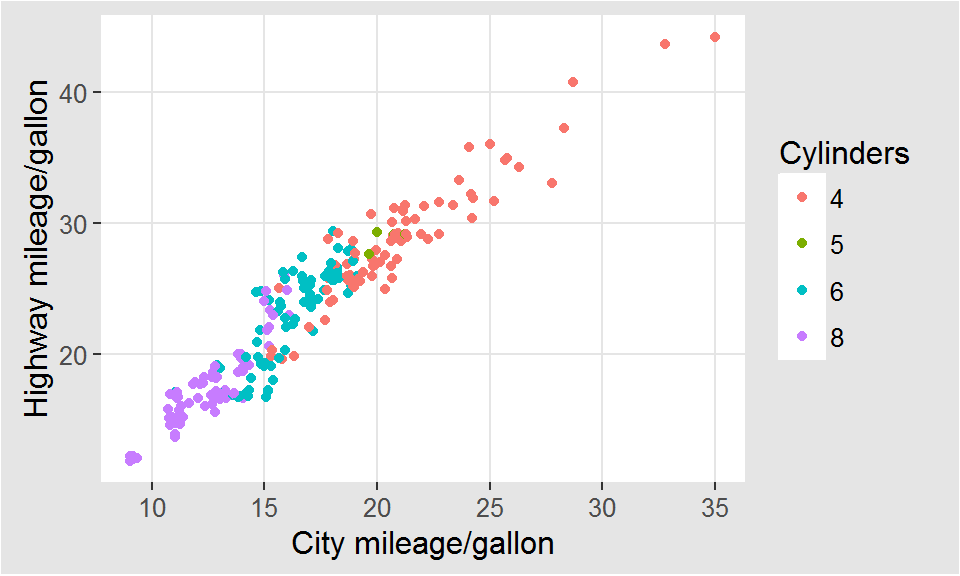

```r
library(ggthemes)
mpg %>% ggplot( aes(x = cty, y = hwy, color = factor(cyl))) +
  geom_jitter() +
  labs(
    x = "City mileage/gallon",
    y = "Highway mileage/gallon",
    color = "Cylinders"
  ) + theme_igray()
```

### Saving themes

If you want all your figures to use a certain theme here is how to do it.

Say my old default theme is `theme_grey()` I have written my own theme called `theme_pink` that I would like to use in all of my plots.

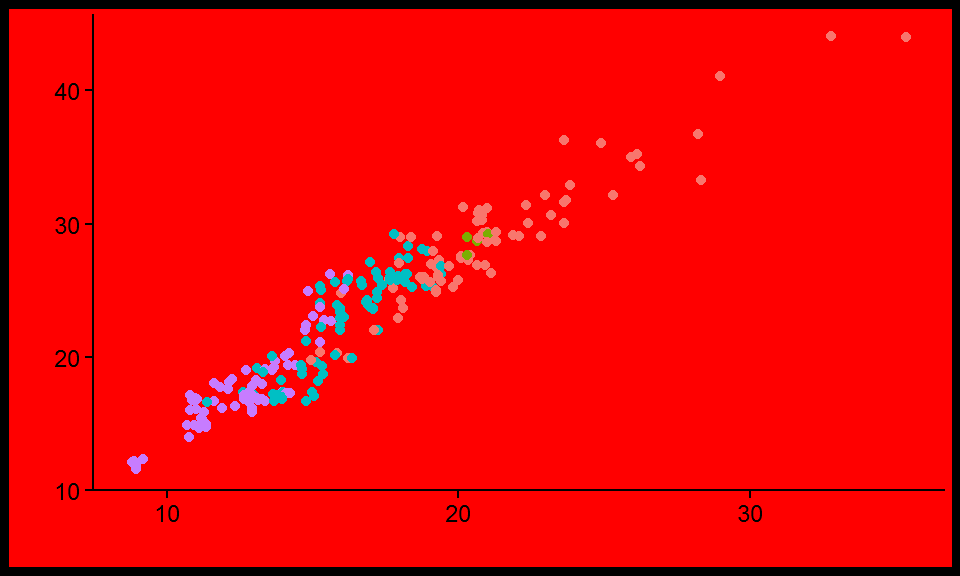

```r
theme_pink <- theme(panel.background = element_blank(),
                    legend.key = element_blank(),
                    legend.background = element_blank(),
                    strip.background = element_blank(),
                    plot.background = element_rect(fill = "red", color = "black", size = 3),
                    panel.grid = element_blank(),
                    axis.line = element_line(color = "black"),
                    axis.ticks = element_line(color = "black"),
                    strip.text = element_text(size = 16, color = "red"),
                    axis.title.y = element_text(color = "red", hjust = 0, face = "italic"),
                    axis.title.x = element_text(color = "red", hjust = 0, face = "italic"),
                    axis.text = element_text(color = "black"),
                    legend.position = "none")


mpg %>% ggplot( aes(x = cty, y = hwy, color = factor(cyl))) +
  geom_jitter() +
  labs(
    x = "City mileage/gallon",
    y = "Highway mileage/gallon",
    color = "Cylinders"
  ) + theme_pink
```

You can make this your default theme using `theme_update()`. The value of the this function is your old theme which you can save: `old <- theme_update()`

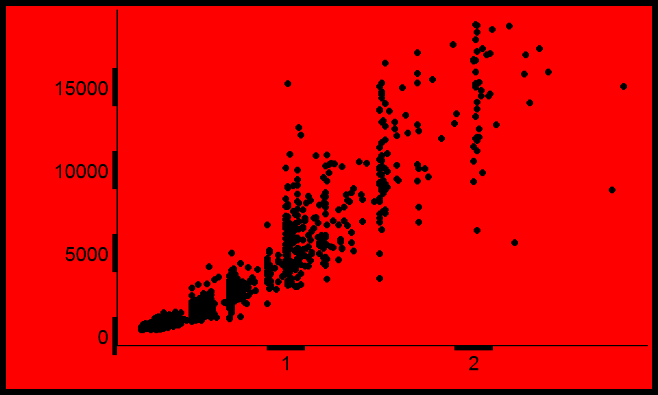

```r
old=theme_update(panel.background = element_blank(),
                    legend.key = element_blank(),
                    legend.background = element_blank(),
                    strip.background = element_blank(),
                    plot.background = element_rect(fill = "red", color = "black", size = 3),
                    panel.grid = element_blank(),
                    axis.line = element_line(color = "black"),
                    axis.ticks = element_line(color = "black"),
                    strip.text = element_text(size = 16, color = "red"),
                    axis.title.y = element_text(color = "red", hjust = 0, face = "italic"),
                    axis.title.x = element_text(color = "red", hjust = 0, face = "italic"),
                    axis.text = element_text(color = "black"),
                    legend.position = "none")


set.seed(123)

df <- diamonds[sample(1:nrow(diamonds), size = 1000),]

df %>% ggplot(aes(carat, price)) +
  geom_point() +
  theme(axis.ticks = element_line(size = 10))
```

You can restore your old theme

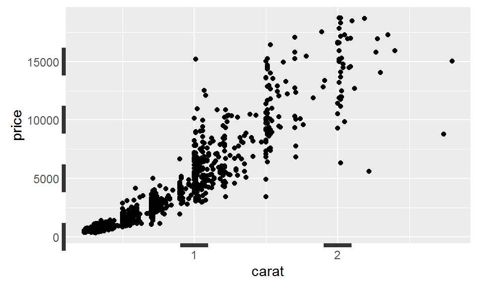

```r
theme_set(old)
set.seed(123)

df <- diamonds[sample(1:nrow(diamonds), size = 1000),]

df %>% ggplot(aes(carat, price)) +
  geom_point() +
  theme(axis.ticks = element_line(size = 10))
```

## Colors in R

Here is a list of [colors](http://www.stat.columbia.edu/~tzheng/files/Rcolor.pdf)

### hexidecimal color code

lecture 17  
# 1. Advanced Looping — `lapply()` and `sapply()` (chapter 4 Data Camp’s Intermediate R)

## Motivation

Here is a function to convert fahrenheit to celsius

```r
to_celsius <- function(x) {
  (x-32)*5/9
}
```

The function `to_celsius` happens to be a vectorized function:

```r
to_celsius(c(32, 40, 50, 60, 70))
```

```
## [1]  0.000000  4.444444 10.000000 15.555556 21.111111
```

Here is another example of a vectorized function:

```r
square_me <- function(vec) vec^2
square_me(c(1,2,3))
```

```
## [1] 1 4 9
```

What happens in this situation?

```r
# trying to_celsius() on a list
to_celsius(list(32, 40, 50, 60, 70))
```

Outputs: Error in x - 32 : non-numeric argument to binary operator

`to_celsius()` does not work with a list.

One solution is to use a for loop:

```r
temps_farhrenheit <- list(c(32, 40, 50, 60, 70))
temps_celsius=c()

for(temp in temps_farhrenheit){
  temps_celsius <- c(temps_celsius,to_celsius(temp))
}
temps_celsius
```

```
## [1]  0.000000  4.444444 10.000000 15.555556 21.111111
```

1. `lapply()`
2. `sapply()`
3. `vapply()`

These functions allow us to avoid writing loops and creates faster more readable code.

The simplest apply function is lapply()

## lapply()

lapply() stands for list apply. It takes a list or vector and a function as inputs and returns a list.

example:

Suppose we want to know the class of the elements of the following list.

```r
nyc <-  list(pop = 8404837, boroughs =c ("Manhattan", "Bronx", "Brooklyn", "Queens", "Staten Island"), capital = FALSE)
```

Instead of writing a for loop to do this you can use `lapply()`

```r
nyc %>% lapply(class)
```

```
## $pop
## [1] "numeric"
##
## $boroughs
## [1] "character"
##
## $capital
## [1] "logical"
```

The output of lapply is a list.

example:

```r
players <- list(
warriors = c('kurry', 'iguodala', 'thompson', 'green'),
cavaliers = c('james', 'shumpert', 'thompson'),
rockets = c('harden', 'howard')
)

players %>% lapply(length)
```

```
## $warriors
## [1] 4
##
## $cavaliers
## [1] 3
##
## $rockets
## [1] 2
```

It applies the function to length() each element of the list. The output is another list.

## Task for you

Here is a list of three vectors of numbers from the normal distribution.

```r
mylist <- list(rnorm(3), rnorm(3), rnorm(5))
mylist
```

```
## [[1]]
## [1] -0.6018928 -0.9936986  1.0267851
##
## [[2]]
## [1]  0.75106130 -1.50916654 -0.09514745
##
## [[3]]
## [1] -0.89594782 -2.07075107  0.15012013 -0.07921171 -0.09736927
```

Find the minimum of each element in mylist.

```r
#using lapply

min_list <- mylist %>% lapply(min) %>% unlist()   #unlist() converts a list to a vector
min_list
```

```
## [1] -0.9936986 -1.5091665 -2.0707511
```

What about functions that take more than one argument?

`paste()` concatenates elements of a vector connecting them with the value of the arguement `collapse`

```r
paste(c("stat", 133, "go"), collapse= "-")
```

```
## [1] "stat-133-go"
```

after the function argument in lapply we put the extra arguements of the functions.

```r
players %>% lapply(paste, collapse = '-')
```

```
## $warriors
## [1] "kurry-iguodala-thompson-green"
##
## $cavaliers
## [1] "james-shumpert-thompson"
##
## $rockets
## [1] "harden-howard"
```

You can use your own functions in `lapply()`

```r
num_chars <- function(x) {
nchar(x)
}
lapply(players, num_chars)
```

```
## $warriors
## [1] 5 8 8 5
##
## $cavaliers
## [1] 5 8 8
##
## $rockets
## [1] 6 6
```

```r
num_chars1 <- function(x,y) {
nchar(x) + y
}
players %>% lapply( num_chars1, 3)
```

```
## $warriors
## [1]  8 11 11  8
##
## $cavaliers
## [1]  8 11 11
##
## $rockets
## [1] 9 9
```

You can define a function with no name (an “anonymous” function)

```r
1:3 %>% lapply(function(x) x^2)
```

```
## [[1]]
## [1] 1
##
## [[2]]
## [1] 4
##
## [[3]]
## [1] 9
```

another example:

the `passte()` function connects the string “mr” with each of the Warrior player’s last name.

```r
paste("mr",c('kurry', 'iguodala', 'thompson', 'green'))
```

```
## [1] "mr kurry"    "mr iguodala" "mr thompson" "mr green"
```

To apply `paste()` to the list of players:

```r
players %>% lapply( function(x) paste("mr",x))
```

```
## $warriors
## [1] "mr kurry"    "mr iguodala" "mr thompson" "mr green"
##
## $cavaliers
## [1] "mr james"    "mr shumpert" "mr thompson"
##
## $rockets
## [1] "mr harden" "mr howard"
```

## Task for you

```r
nchar(c("adam","jim"))
```

```
## [1] 4 3
```

Use lapply to add two to the number of characters in each of player’s name in `players`

```r
players %>% lapply(function(x) nchar(x) +2)
```

```
## $warriors
## [1]  7 10 10  7
##
## $cavaliers
## [1]  7 10 10
##
## $rockets
## [1] 8 8
```

Remember that a data.frame and a matrix is internally stored as a list.

```r
df <- data.frame(
  name = c('Luke', 'Leia', 'R2-D2', 'C-3PO'),
  gender = c('male', 'female', 'male', 'male'),
  height = c(1.72, 1.50, 0.96, 1.67),
  weight = c(77, 49, 32, 75)
)

df %>% lapply(class)
```

```
## $name
## [1] "factor"
##
## $gender
## [1] "factor"
##
## $height
## [1] "numeric"
##
## $weight
## [1] "numeric"
```

## sapply

`sapply()` is a modified version of `lapply()`.

`sapply() stands for simplified apply and will output the result as an array if possilbe.

```r
1:3 %>% sapply(function(x) x^2)
```

```
## [1] 1 4 9
```

Here we output a 1 dimensional array (i.e. a vector) Notice this is the same as

```r
1:3 %>% lapply(function(x) x^2) %>% unlist()
```

```
## [1] 1 4 9
```

We have seen examples where the list output by `lapply()` have elements that are vectors of different size. It isn’t possible to coerce this to be an array since all the rows of an array must be the same size. However, if the output of lapply() has vectors of equal length, we can display our results as an array. `

for example:

```r
first_and_last <- function(name){
    name <-  gsub(" ","",name)
    letters <-  strsplit(name,split = "")[[1]]
    c(first=min(letters), last=max(letters))
}

first_and_last("New York")
```

```
## first  last
##   "e"   "Y"
```

now lets apply this function to the following vector of cities.

```r
cities <- c("New York", "Paris", "London", "Tokyo", "Rio de Janeiro", "Cape Town")

cities %>% sapply(first_and_last)
```

|  | New York | Paris | London | Tokyo | Rio de Janeiro | Cape Town |
| --- | --- | --- | --- | --- | --- | --- |
| first | e | a | d | k | a | a |
| last | Y | s | o | y | R | w |

Lecture 19  
Distributions and Statistics

Good comparision

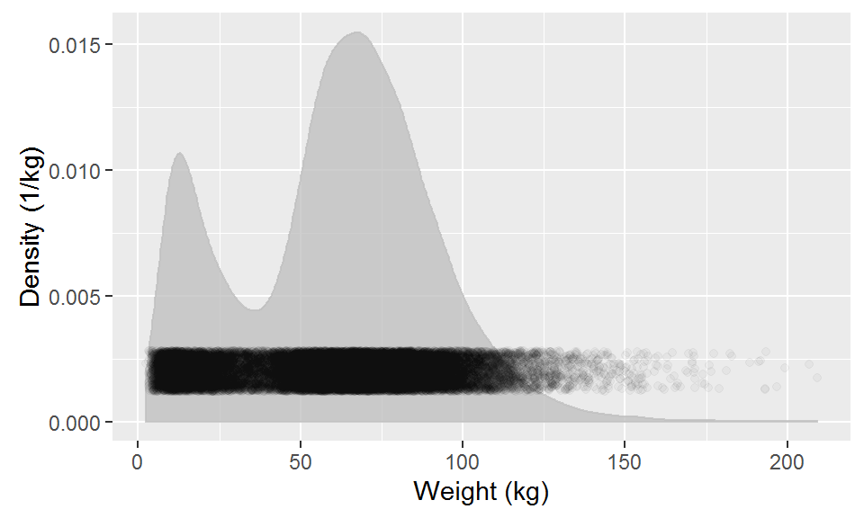

```r
ggplot( NCHS, aes(x=weight) ) +
  geom_density(color="gray", fill="gray", alpha=.75) +
  geom_point( alpha=.03, position=position_jitter(height=.002), aes(y=0.002)) +
  xlab("Weight (kg)") + ylab( "Density (1/kg)")
```

Breaking to chunks

```r
NCHS1 <- NCHS %>%
  mutate( ageGroup= ntiles(age, n=6, format="interval") )
```

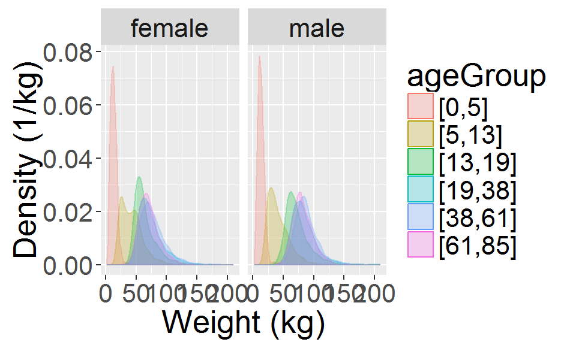

```r
NCHS1 %>%
  ggplot( aes(x=weight, group=ageGroup) ) +
  geom_density(aes(color=ageGroup, fill=ageGroup), alpha=.25) +
  xlab("Weight (kg)") + ylab( "Density (1/kg)") +
  facet_wrap( ~ sex ) + theme(text = element_text(size = 20))
```

The *violin* glyph provides a similar ease of comparison to the box-and-whisker glyph, but shows more detail in the density.

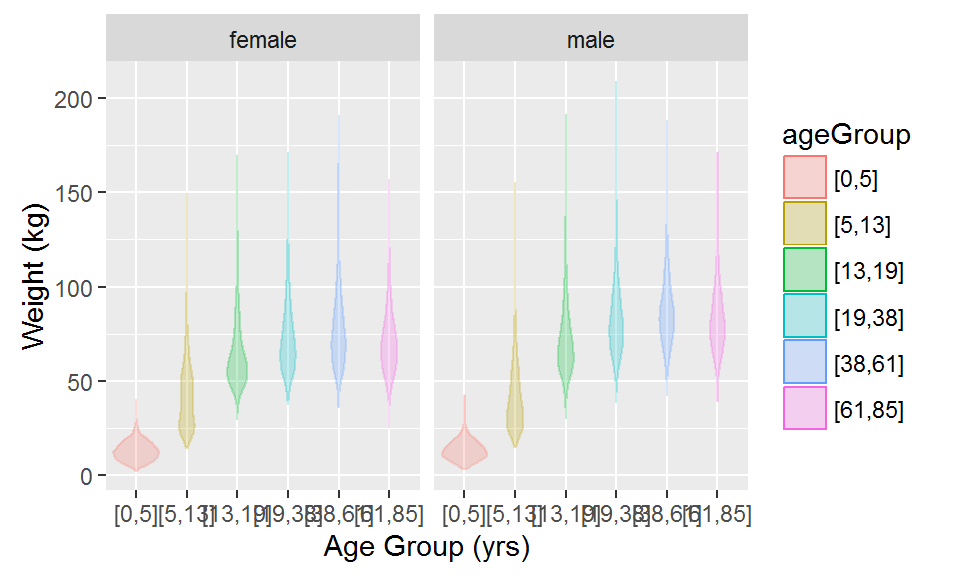

```r
NCHS1 %>%
  ggplot( aes(y=weight, x=ageGroup) ) +
  geom_violin( aes(color=ageGroup, fill=ageGroup),
    alpha=.25) +
  ylab("Weight (kg)") + xlab( "Age Group (yrs)") +
  facet_wrap( ~ sex )
```

```r
Diabetics <-
  NCHS1 %>% filter( diabetic=="Diabetic" )
```

```r
Nondiabetics <-
  NCHS1 %>% filter( diabetic=="Not" )
```

[figure not shown]

```r
Nondiabetics %>%
  ggplot( aes(y=weight, x=ageGroup) ) +
  geom_boxplot(
    aes(color=ageGroup, fill=ageGroup),
    alpha=.25, outlier.size=1, outlier.colour="gray") +
  ylab("Weight (kg)") + xlab( "Age Group (yrs)") +
  geom_boxplot( data=Diabetics, width=.3,color='red',
                outlier.colour="lightpink",alpha=.2)
```

Maybe this is a better graph?

[figure not shown]

```r
NCHS1 %>%
  ggplot(aes(y=weight, x=ageGroup)) +
    geom_boxplot(aes(fill=diabetic), position = position_dodge(width = 0.8),outlier.size = 1, outlier.colour = "gray", alpha=.75) +
    facet_grid(.~sex) +
    ylab("Weight (kg)") +
    xlab("Age Group (yrs)")
```

A box-and-whiskers glyph can show the confidence interval of the median by means of a “notch”. There is a 95% chance that the notch contains the true wage median. Overlap between the notches in two boxes indicates that the evidence for a difference is weak.

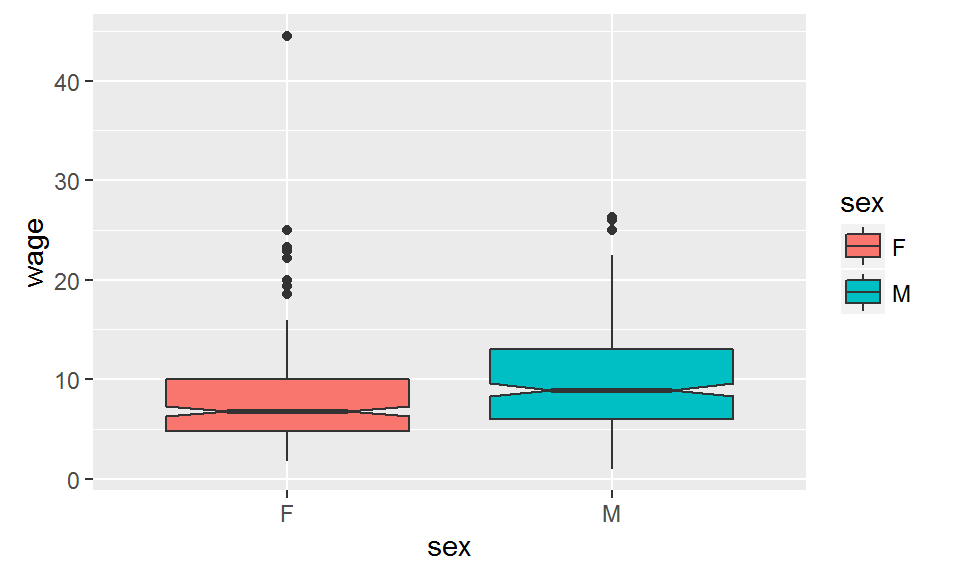

```r
CPS85 %>%
  ggplot(aes(x=sex,y=wage)) + geom_boxplot(aes( fill=sex), notch = TRUE)
```

[figure not shown]

```r
NCHS1 %>%
  ggplot(aes(y=weight, x=ageGroup)) + geom_boxplot(aes(fill=diabetic), notch=TRUE, position = position_dodge(width = 0.8),outlier.size = 1, outlier.colour = "gray", alpha=.75) + facet_grid(.~sex) + ylab("Weight (kg)") + xlab("Age Group (yrs)")
```

[figure not shown]

```r
NCHS %>%
  ggplot( aes(x=age, y=weight, color=diabetic ) ) +
  stat_smooth( ) +
  geom_point( data=Diabetics, color="red", alpha=.2)
```

This sort of function, called a “smoother”, is able to bend with the data. A much more commonly used function — the “linear” function — is utterly stiff; it can’t bend at all. You can construct this sort of function from the data with `method=lm` as an argument to `stat_smooth()`.

[figure not shown]

```r
NCHS %>%
  ggplot( aes(x=age, y=weight, color=diabetic ) ) +
  stat_smooth( method=lm ) +
  geom_point( data=Diabetics, color="red", alpha=.2)
```